# Regression Model for [Project Name] Using R version 05.0

### 2.b) Data visualizations

[figure not shown]

```r
# Boxplots for each attribute
par(mfrow=c(dispRow,dispCol))
for(i in 1:totAttr) {
    boxplot(x_train[,i], main=names(x_train)[i])
}
```

[figure not shown]

```r
# Histograms each attribute
par(mfrow=c(dispRow,dispCol))
for(i in 1:totAttr) {
    hist(x_train[,i], main=names(x_train)[i])
}
```

[figure not shown]

```r
# Density plot for each attribute
par(mfrow=c(dispRow,dispCol))
for(i in 1:totAttr) {
    plot(density(x_train[,i]), main=names(x_train)[i])
}
```

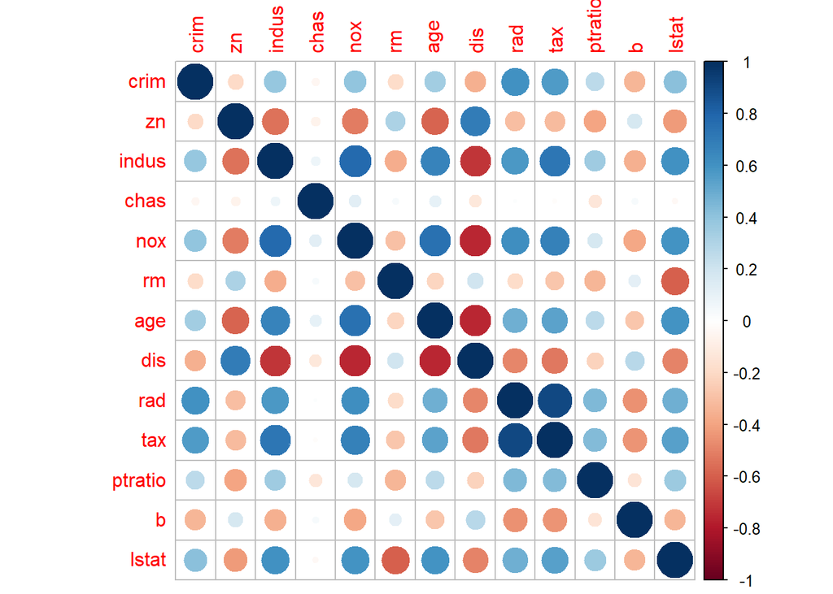

```r
# Correlation plot
correlations <- cor(x_train)
corrplot(correlations, method="circle")
```

## 3. Prepare Data

Some dataset may require additional preparation activities that will best exposes the structure of the problem and the relationships between the input attributes and the output variable. Some data-prep tasks might include:

- Cleaning data by removing duplicates, marking missing values and even imputing missing values.
- Feature selection where redundant features may be removed.
- Data transforms where attributes are scaled or redistributed in order to best expose the structure of the problem later to learning algorithms.

### 3.a) Data Cleaning

```r
# Not applicable for this iteration of the project.

# Mark missing values
#invalid <- 0
#entireDataset$some_col[entireDataset$some_col==invalid] <- NA

# Impute missing values
#entireDataset$some_col <- with(entireDataset, impute(some_col, mean))
```

### 3.b) Feature Selection

```r
# Not applicable for this iteration of the project.
```

### 3.c) Data Transforms

```r
# Not applicable for this iteration of the project.
```

```r
proc.time()-startTimeScript
```

```
##    user  system elapsed
##    4.49    1.86    6.46
```

## 4. Model and Evaluate Algorithms

After the data-prep, we next work on finding a workable model by evaluating a subset of machine learning algorithms that are good at exploiting the structure of the dataset. The typical evaluation tasks include:

- Defining test options such as cross validation and the evaluation metric to use.
- Spot checking a suite of linear and nonlinear machine learning algorithms.
- Comparing the estimated accuracy of algorithms.

For this project, we will evaluate one linear, three non-linear, and three ensemble algorithms:

Linear Algorithm: Linear Regression

Non-Linear Algorithms: Decision Trees (CART), k-Nearest Neighbors, and Support Vector Machine

Ensemble Algorithms: Bagged CART, Random Forest, and Stochastic Gradient Boosting

The random number seed is reset before each run to ensure that the evaluation of each algorithm is performed using the same data splits. It ensures the results are directly comparable.

### 4.a) Generate models using linear algorithms

```r
# Linear Regression (Regression)
startTimeModule <- proc.time()
set.seed(seedNum)
fit.lm <- train(targetVar~., data=xy_train, method="lm", metric=metricTarget, trControl=control)
print(fit.lm)
```

```
## Linear Regression
##
## 356 samples
##  13 predictor
##
## No pre-processing
## Resampling: Cross-Validated (10 fold, repeated 3 times)
## Summary of sample sizes: 320, 321, 322, 320, 320, 319, ...
## Resampling results:
##
##   RMSE      Rsquared   MAE
##   4.726392  0.7376981  3.304634
##
## Tuning parameter 'intercept' was held constant at a value of TRUE
```

```r
proc.time()-startTimeModule
```

```
##    user  system elapsed
##    0.72    0.02    0.74
```

### 4.b) Generate models using nonlinear algorithms

```r
# Decision Tree - CART (Regression/Classification)
startTimeModule <- proc.time()
set.seed(seedNum)
fit.cart <- train(targetVar~., data=xy_train, method="rpart", metric=metricTarget, trControl=control)
print(fit.cart)
```

```
## CART
##
## 356 samples
##  13 predictor
##
## No pre-processing
## Resampling: Cross-Validated (10 fold, repeated 3 times)
## Summary of sample sizes: 320, 321, 322, 320, 320, 319, ...
## Resampling results across tuning parameters:
##
##   cp          RMSE      Rsquared   MAE
##   0.06403144  5.646914  0.5917722  4.224575
##   0.20210303  7.054116  0.3827243  5.299967
##   0.43646222  8.028981  0.3036675  5.944589
##
## RMSE was used to select the optimal model using the smallest value.
## The final value used for the model was cp = 0.06403144.
```

```r
proc.time()-startTimeModule
```

```
##    user  system elapsed
##    0.88    0.03    0.90
```

```r
# k-Nearest Neighbors (Regression/Classification)
startTimeModule <- proc.time()
set.seed(seedNum)
fit.knn <- train(targetVar~., data=xy_train, method="knn", metric=metricTarget, trControl=control)
print(fit.knn)
```

```
## k-Nearest Neighbors
##
## 356 samples
##  13 predictor
##
## No pre-processing
## Resampling: Cross-Validated (10 fold, repeated 3 times)
## Summary of sample sizes: 320, 321, 322, 320, 320, 319, ...
## Resampling results across tuning parameters:
##
##   k  RMSE      Rsquared   MAE
##   5  6.270063  0.5244869  4.328750
##   7  6.554145  0.4746715  4.556952
##   9  6.676412  0.4535772  4.598905
##
## RMSE was used to select the optimal model using the smallest value.
## The final value used for the model was k = 5.
```

```r
proc.time()-startTimeModule
```

```
##    user  system elapsed
##    0.84    0.00    0.94
```

```r
# Support Vector Machine (Regression/Classification)
startTimeModule <- proc.time()
set.seed(seedNum)
fit.svm <- train(targetVar~., data=xy_train, method="svmRadial", metric=metricTarget, trControl=control)
print(fit.svm)
```

```
## Support Vector Machines with Radial Basis Function Kernel
##
## 356 samples
##  13 predictor
##
## No pre-processing
## Resampling: Cross-Validated (10 fold, repeated 3 times)
## Summary of sample sizes: 320, 321, 322, 320, 320, 319, ...
## Resampling results across tuning parameters:
##
##   C     RMSE      Rsquared   MAE
##   0.25  5.027238  0.7327892  2.976832
##   0.50  4.434495  0.7802020  2.646797
##   1.00  3.926814  0.8198316  2.416313
##
## Tuning parameter 'sigma' was held constant at a value of 0.1297821
## RMSE was used to select the optimal model using the smallest value.
## The final values used for the model were sigma = 0.1297821 and C = 1.
```

```r
proc.time()-startTimeModule
```

```
##    user  system elapsed
##    2.93    0.11    3.10
```

### 4.c) Generate models using ensemble algorithms

In this section, we will explore the use and tuning of ensemble algorithms to see whether we can improve the results.

```r
# Bagged CART (Regression/Classification)
startTimeModule <- proc.time()
set.seed(seedNum)
fit.bagcart <- train(targetVar~., data=xy_train, method="treebag", metric=metricTarget, trControl=control)
print(fit.bagcart)
```

```
## Bagged CART
##
## 356 samples
##  13 predictor
##
## No pre-processing
## Resampling: Cross-Validated (10 fold, repeated 3 times)
## Summary of sample sizes: 320, 321, 322, 320, 320, 319, ...
## Resampling results:
##
##   RMSE    Rsquared   MAE
##   3.9437  0.8041574  2.759253
```

```r
proc.time()-startTimeModule
```

```
##    user  system elapsed
##    3.98    0.01    4.04
```

```r
# Random Forest (Regression/Classification)
startTimeModule <- proc.time()
set.seed(seedNum)
fit.rf <- train(targetVar~., data=xy_train, method="rf", metric=metricTarget, trControl=control)
print(fit.rf)
```

```
## Random Forest
##
## 356 samples
##  13 predictor
##
## No pre-processing
## Resampling: Cross-Validated (10 fold, repeated 3 times)
## Summary of sample sizes: 320, 321, 322, 320, 320, 319, ...
## Resampling results across tuning parameters:
##
##   mtry  RMSE      Rsquared   MAE
##    2    3.587251  0.8605082  2.429433
##    7    3.165290  0.8787203  2.215869
##   13    3.170584  0.8752985  2.280172
##
## RMSE was used to select the optimal model using the smallest value.
## The final value used for the model was mtry = 7.
```

```r
proc.time()-startTimeModule
```

```
##    user  system elapsed
##   46.98    1.51   48.62
```

```r
# Stochastic Gradient Boosting (Regression/Classification)
startTimeModule <- proc.time()
set.seed(seedNum)
fit.gbm <- train(targetVar~., data=xy_train, method="gbm", metric=metricTarget, trControl=control, verbose=F)
print(fit.gbm)
```

```
## Stochastic Gradient Boosting
##
## 356 samples
##  13 predictor
##
## No pre-processing
## Resampling: Cross-Validated (10 fold, repeated 3 times)
## Summary of sample sizes: 320, 321, 322, 320, 320, 319, ...
## Resampling results across tuning parameters:
##
##   interaction.depth  n.trees  RMSE      Rsquared   MAE
##   1                   50      4.148822  0.7885443  2.887682
##   1                  100      3.810195  0.8178430  2.630270
##   1                  150      3.713686  0.8280044  2.583732
##   2                   50      3.683481  0.8296915  2.543735
##   2                  100      3.428157  0.8525690  2.385490
##   2                  150      3.346652  0.8601643  2.357690
##   3                   50      3.527889  0.8438402  2.436613
##   3                  100      3.282399  0.8658854  2.307819
##   3                  150      3.204242  0.8719423  2.272195
##
## Tuning parameter 'shrinkage' was held constant at a value of 0.1
##
## Tuning parameter 'n.minobsinnode' was held constant at a value of 10
## RMSE was used to select the optimal model using the smallest value.
## The final values used for the model were n.trees = 150,
##  interaction.depth = 3, shrinkage = 0.1 and n.minobsinnode = 10.
```

```r
proc.time()-startTimeModule
```

```
##    user  system elapsed
##    2.87    0.03    2.91
```

### 4.d) Compare baseline algorithms

```r
results <- resamples(list(LR=fit.lm, CART=fit.cart, kNN=fit.knn, SVM=fit.svm, BagCART=fit.bagcart, RF=fit.rf, GBM=fit.gbm))
summary(results)
```

```
##
## Call:
## summary.resamples(object = results)
##
## Models: LR, CART, kNN, SVM, BagCART, RF, GBM
## Number of resamples: 30
##
## MAE
##             Min.  1st Qu.   Median     Mean  3rd Qu.     Max. NA's
## LR      2.301582 2.946533 3.291963 3.304634 3.609415 4.310249    0
## CART    2.849549 3.853591 4.396253 4.224575 4.621135 5.345897    0
## kNN     3.473889 3.751806 4.289630 4.328750 4.621471 6.313889    0
## SVM     1.725803 2.116943 2.307146 2.416313 2.832899 3.360491    0
## BagCART 1.874551 2.474610 2.746754 2.759253 3.038521 3.778367    0
## RF      1.520776 1.995293 2.115102 2.215869 2.494213 3.231470    0
## GBM     1.644335 2.029451 2.283797 2.272195 2.565908 3.011619    0
##
## RMSE
##             Min.  1st Qu.   Median     Mean  3rd Qu.     Max. NA's
## LR      2.996877 3.952643 4.613754 4.726392 5.592376 6.208387    0
## CART    3.686359 4.909180 5.646577 5.646914 6.346675 7.331976    0
## kNN     4.452593 5.295896 6.084449 6.270063 7.101595 8.166050    0
## SVM     2.286760 3.096261 3.712438 3.926814 4.560332 6.357293    0
## BagCART 2.114560 3.264479 3.807872 3.943700 4.710137 6.070829    0
## RF      1.818506 2.559000 2.906247 3.165290 3.761177 5.134656    0
## GBM     1.937299 2.794474 3.050067 3.204242 3.679277 4.896349    0
##
## Rsquared
##              Min.   1st Qu.    Median      Mean   3rd Qu.      Max. NA's
## LR      0.5756919 0.6651520 0.7394332 0.7376981 0.8106141 0.8943016    0
## CART    0.2911869 0.5154461 0.5885874 0.5917722 0.6836724 0.8491612    0
## kNN     0.2331555 0.4585583 0.5094373 0.5244869 0.6061677 0.7423916    0
## SVM     0.5831170 0.7730804 0.8461626 0.8198316 0.8987294 0.9280844    0
## BagCART 0.6015748 0.7691139 0.8100931 0.8041574 0.8724906 0.9383368    0
## RF      0.7232520 0.8506294 0.8757537 0.8787203 0.9183302 0.9539289    0
## GBM     0.7450362 0.8369885 0.8803425 0.8719423 0.9126391 0.9431610    0
```

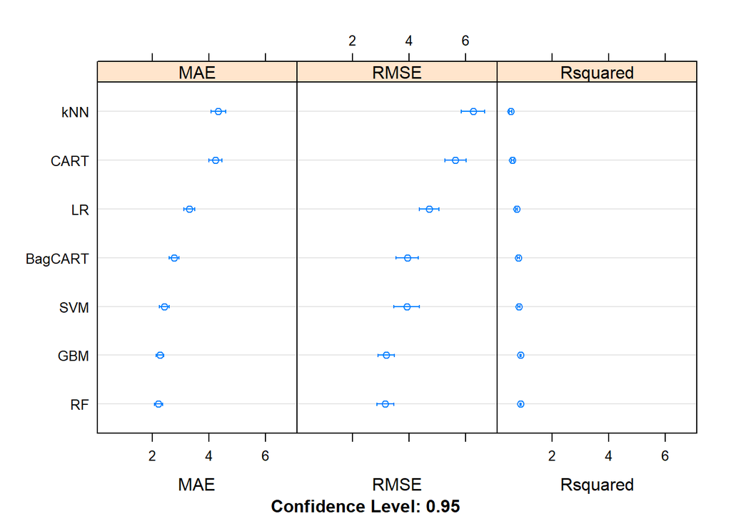

```r
dotplot(results)
```

```r
cat('The average RMSE from all models is:',
    mean(c(results$values$`LR~RMSE`,results$values$`CART~RMSE`,results$values$`kNN~RMSE`,results$values$`SVM~RMSE`,results$values$`BagCART~RMSE`,results$values$`RF~RMSE`,results$values$`GBM~RMSE`)))
```

```
## The average RMSE from all models is: 4.411917
```

## 5. Improve Accuracy or Results

After we achieve a short list of machine learning algorithms with good level of accuracy, we can leverage ways to improve the accuracy of the models.

Using the three best-perfoming algorithms from the previous section, we will Search for a combination of parameters for each algorithm that yields the best results.

### 5.a) Algorithm Tuning

Finally, we will tune the best-performing algorithms from each group further and see whether we can get more accuracy out of them.

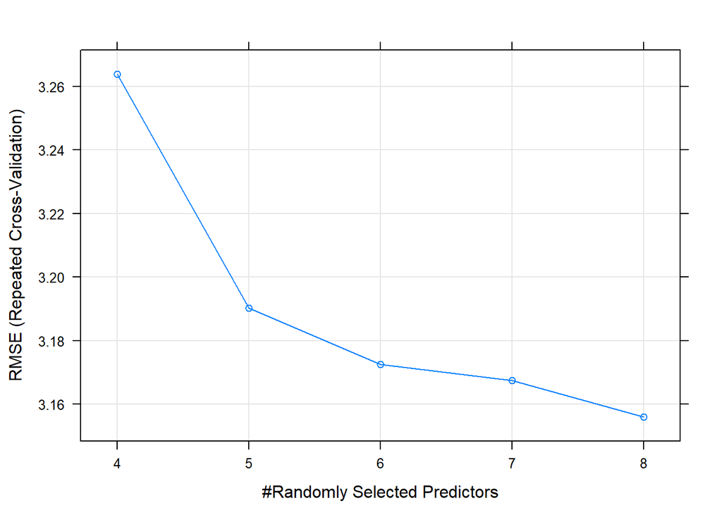

```r
# Tuning algorithm #1 - Random Forest
startTimeModule <- proc.time()
set.seed(seedNum)
grid <- expand.grid(mtry = c(4:8))
fit.final1 <- train(targetVar~., data=xy_train, method="rf", metric=metricTarget, tuneGrid=grid, trControl=control)
plot(fit.final1)
```

```r
print(fit.final1)
```

```
## Random Forest
##
## 356 samples
##  13 predictor
##
## No pre-processing
## Resampling: Cross-Validated (10 fold, repeated 3 times)
## Summary of sample sizes: 320, 321, 322, 320, 320, 319, ...
## Resampling results across tuning parameters:
##
##   mtry  RMSE      Rsquared   MAE
##   4     3.263938  0.8760094  2.230938
##   5     3.190187  0.8806825  2.220349
##   6     3.172565  0.8803278  2.219597
##   7     3.167402  0.8795473  2.218131
##   8     3.155904  0.8793468  2.227982
##
## RMSE was used to select the optimal model using the smallest value.
## The final value used for the model was mtry = 8.
```

```r
proc.time()-startTimeModule
```

```
##    user  system elapsed
##   68.09    2.61   71.46
```

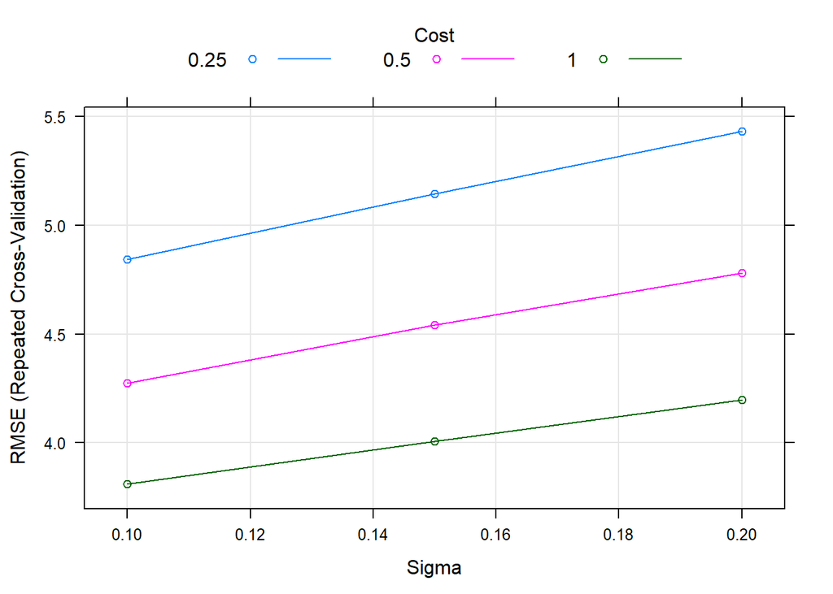

```r
# Tuning algorithm #2 - Support Vector Machine
startTimeModule <- proc.time()
set.seed(seedNum)
grid <- expand.grid(sigma = c(0.10, 0.15, 0.20), C = c(0.25, 0.5, 1.0))
fit.final2 <- train(targetVar~., data=xy_train, method="svmRadial", metric=metricTarget, tuneGrid=grid, trControl=control)
plot(fit.final2)
```

```r
print(fit.final2)
```

```
## Support Vector Machines with Radial Basis Function Kernel
##
## 356 samples
##  13 predictor
##
## No pre-processing
## Resampling: Cross-Validated (10 fold, repeated 3 times)
## Summary of sample sizes: 320, 321, 322, 320, 320, 319, ...
## Resampling results across tuning parameters:
##
##   sigma  C     RMSE      Rsquared   MAE
##   0.10   0.25  4.843358  0.7492866  2.891098
##   0.10   0.50  4.272621  0.7943010  2.554393
##   0.10   1.00  3.809400  0.8298915  2.343418
##   0.15   0.25  5.143501  0.7224051  3.029777
##   0.15   0.50  4.540792  0.7705679  2.705092
##   0.15   1.00  4.007441  0.8124234  2.463676
##   0.20   0.25  5.431145  0.6950355  3.192584
##   0.20   0.50  4.780752  0.7488138  2.844618
##   0.20   1.00  4.196418  0.7957156  2.585268
##
## RMSE was used to select the optimal model using the smallest value.
## The final values used for the model were sigma = 0.1 and C = 1.
```

```r
proc.time()-startTimeModule
```

```
##    user  system elapsed
##    5.64    0.47    6.11
```

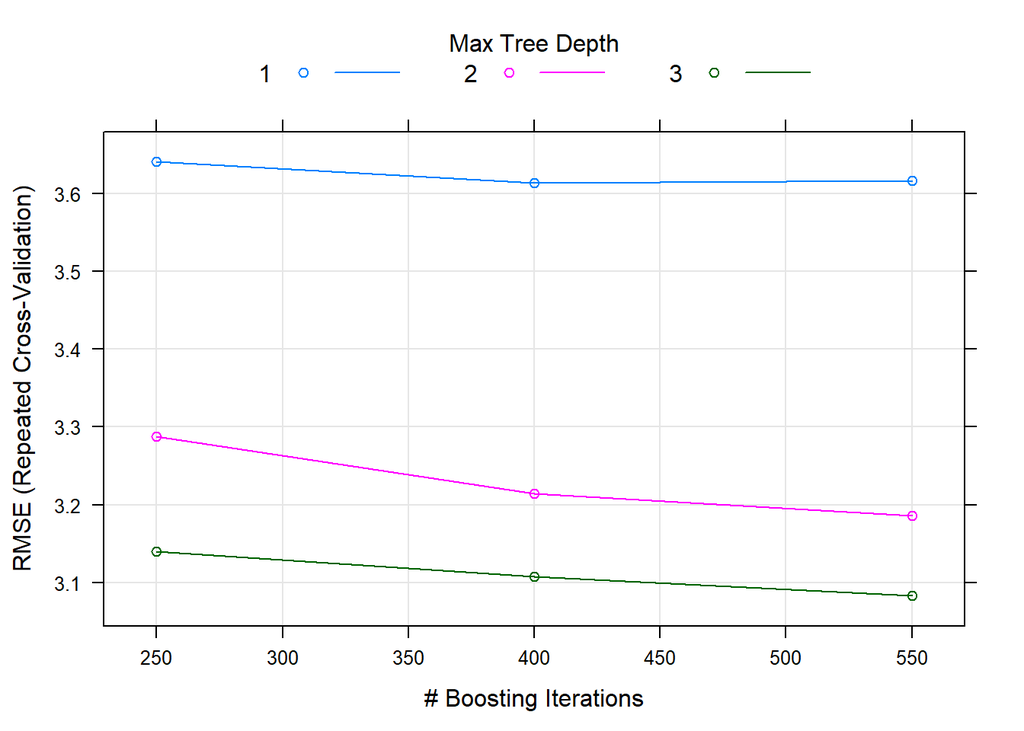

```r
# Tuning algorithm #3 - Stochastic Gradient Boosting
startTimeModule <- proc.time()
set.seed(seedNum)
grid <- expand.grid(.n.trees=c(250, 400, 550), .shrinkage=0.1, .interaction.depth=c(1, 2, 3), .n.minobsinnode=10)
fit.final3 <- train(targetVar~., data=xy_train, method="gbm", metric=metricTarget, tuneGrid=grid, trControl=control, verbose=F)
plot(fit.final3)
```

```r
print(fit.final3)
```

```
## Stochastic Gradient Boosting
##
## 356 samples
##  13 predictor
##
## No pre-processing
## Resampling: Cross-Validated (10 fold, repeated 3 times)
## Summary of sample sizes: 320, 321, 322, 320, 320, 319, ...
## Resampling results across tuning parameters:
##
##   interaction.depth  n.trees  RMSE      Rsquared   MAE
##   1                  250      3.640600  0.8351085  2.575785
##   1                  400      3.613151  0.8385941  2.584950
##   1                  550      3.616891  0.8386041  2.600661
##   2                  250      3.288194  0.8648606  2.348197
##   2                  400      3.214728  0.8712657  2.311304
##   2                  550      3.186292  0.8734692  2.297406
##   3                  250      3.139674  0.8773622  2.241331
##   3                  400      3.107980  0.8793947  2.209955
##   3                  550      3.083000  0.8810188  2.199899
##
## Tuning parameter 'shrinkage' was held constant at a value of 0.1
##
## Tuning parameter 'n.minobsinnode' was held constant at a value of 10
## RMSE was used to select the optimal model using the smallest value.
## The final values used for the model were n.trees = 550,
##  interaction.depth = 3, shrinkage = 0.1 and n.minobsinnode = 10.
```

```r
proc.time()-startTimeModule
```

```
##    user  system elapsed
##    7.11    0.03    7.14
```

### 5.d) Compare Algorithms After Tuning

```r
results <- resamples(list(RF=fit.final1, SVM=fit.final2, GBM=fit.final3))
summary(results)
```

```
##
## Call:
## summary.resamples(object = results)
##
## Models: RF, SVM, GBM
## Number of resamples: 30
##
## MAE
##         Min.  1st Qu.   Median     Mean  3rd Qu.     Max. NA's
## RF  1.500965 2.010572 2.123191 2.227982 2.509488 3.179296    0
## SVM 1.689439 2.061385 2.196989 2.343418 2.773121 3.284132    0
## GBM 1.523316 1.955624 2.185134 2.199899 2.438750 2.696548    0
##
## RMSE
##         Min.  1st Qu.   Median     Mean  3rd Qu.     Max. NA's
## RF  1.791603 2.540634 2.976941 3.155904 3.784918 4.952511    0
## SVM 2.229364 2.817439 3.536358 3.809400 4.460976 6.055463    0
## GBM 1.846271 2.582413 2.983756 3.083000 3.514860 4.335735    0
##
## Rsquared
##          Min.   1st Qu.    Median      Mean   3rd Qu.      Max. NA's
## RF  0.7452879 0.8588424 0.8733674 0.8793468 0.9162050 0.9526118    0
## SVM 0.6043046 0.7727422 0.8505322 0.8298915 0.9001536 0.9396104    0
## GBM 0.7972794 0.8493819 0.8906447 0.8810188 0.9160784 0.9558048    0
```

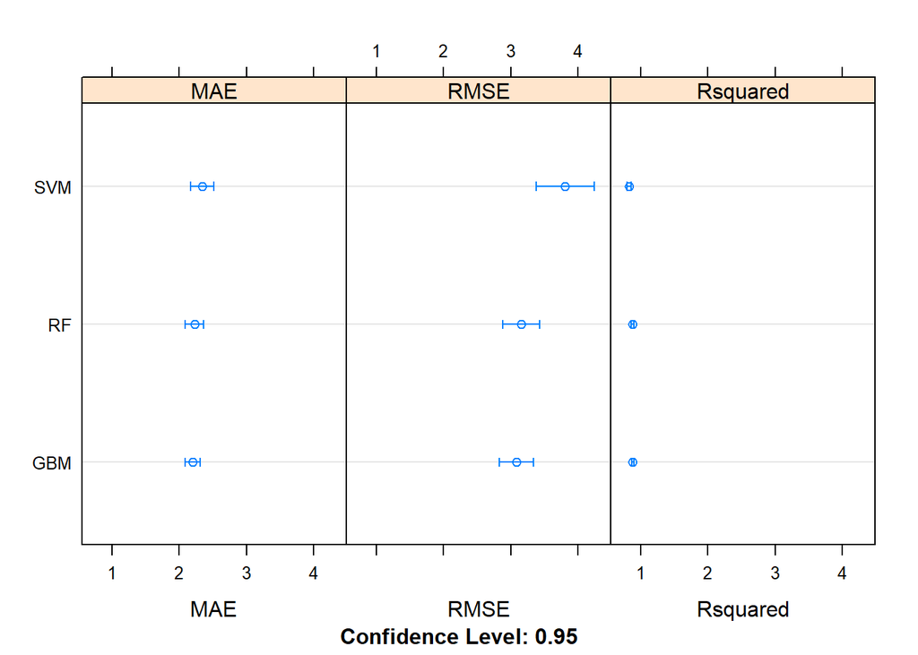

```r
dotplot(results)
```

## 6. Finalize Model and Present Results

Once we have narrow down to a model that we believe can make accurate predictions on unseen data, we are ready to finalize it. Finalizing a model may involve sub-tasks such as:

- Using an optimal model tuned to make predictions on unseen data.
- Creating a standalone model using the tuned parameters
- Saving an optimal model to file for later use.

### 6.a) Predictions on validation dataset

```r
predictions <- predict(fit.final3, newdata=xy_test)
print(RMSE(predictions, y_test))
```

```
## [1] 3.554948
```

```r
print(R2(predictions, y_test))
```

```
## [1] 0.8659327
```

### 6.b) Create standalone model on entire training dataset

```r
startTimeModule <- proc.time()
library(gbm)
set.seed(seedNum)
finalModel <- gbm(targetVar~., data=xy_train, n.trees=550, shrinkage=0.1, interaction.depth=3, n.minobsinnode=10)
```

```
## Distribution not specified, assuming gaussian ...
```

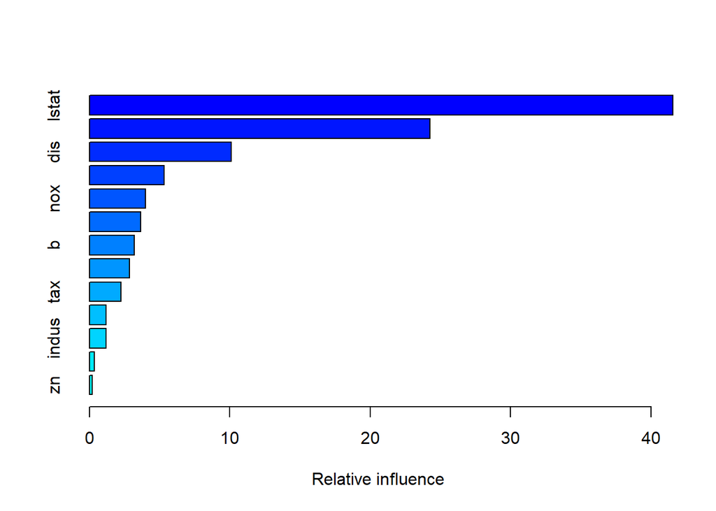

```
##             var    rel.inf
## lstat     lstat 41.5680885
## rm           rm 24.2611624
## dis         dis 10.0965978
## crim       crim  5.3161538
## nox         nox  3.9815027
## age         age  3.6507837
## b             b  3.1776088
## ptratio ptratio  2.8458031
## tax         tax  2.2304691
## chas       chas  1.1858692
## indus     indus  1.1624308
## rad         rad  0.3467339
## zn           zn  0.1767962
```

```r
summary(finalModel)
```

```r
proc.time()-startTimeModule
```

```
##    user  system elapsed
##    0.16    0.01    0.17
```

### 6.c) Save model for later use

```r
#saveRDS(finalModel, "./finalModel_Regression.rds")
```

```r
proc.time()-startTimeScript
```

```
##    user  system elapsed
##  145.75    7.16  154.08
```